# February 27

## Packages

```r
library(tidyverse)
library(broom)
library(car)
library(lme4) # for mixed models repeated measures, later
```

## Analysis of covariance

slide 270 for background, 271 for data

```r
my_url="http://www.utsc.utoronto.ca/~butler/d29/ancova.txt"
prepost=read_delim(my_url," ")
prepost
```

| drug | before | after |
| --- | --- | --- |
| a | 5 | 20 |
| a | 10 | 23 |
| a | 12 | 30 |
| a | 9 | 25 |
| a | 23 | 34 |
| a | 21 | 40 |
| a | 14 | 27 |
| a | 18 | 38 |
| a | 6 | 24 |
| a | 13 | 31 |

[output cut: 10 more lines]

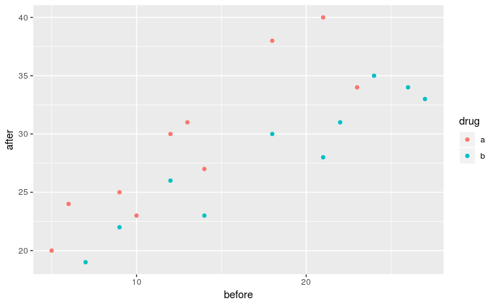

```r
ggplot(prepost,aes(x=before,y=after,colour=drug))+
  geom_point()
```

compare before and after means of each drug

```r
prepost %>% group_by(drug) %>%
summarize(before_mean=mean(before),
          after_mean=mean(after))
```

| drug | before_mean | after_mean |
| --- | --- | --- |
| a | 13.1 | 29.2 |
| b | 18.0 | 28.1 |

analysis with interaction

```r
prepost.1=lm(after~before*drug,data=prepost)
anova(prepost.1)
```

```
Analysis of Variance Table

Response: after
            Df Sum Sq Mean Sq F value    Pr(>F)
before       1 430.92  430.92 62.6894  6.34e-07 ***
drug         1 115.31  115.31 16.7743 0.0008442 ***
before:drug  1  12.34   12.34  1.7948 0.1990662
Residuals   16 109.98    6.87
---
Signif. codes:  0 ‘***’ 0.001 ‘**’ 0.01 ‘*’ 0.05 ‘.’ 0.1 ‘ ’ 1
```

interaction not significant, remove (later), but first, predictions:

```r
new=crossing(
before=c(5,15,25),
drug=c("a","b"))
new
```

| before | drug |
| --- | --- |
| 5 | a |
| 5 | b |
| 15 | a |
| 15 | b |
| 25 | a |
| 25 | b |

and then predict:

```r
pred=predict(prepost.1,new)
preds=bind_cols(new,pred=pred)
preds
```

| before | drug | pred |
| --- | --- | --- |
| 5 | a | 21.29948 |
| 5 | b | 18.71739 |
| 15 | a | 31.05321 |
| 15 | b | 25.93478 |
| 25 | a | 40.80693 |
| 25 | b | 33.15217 |

plot data with predictions

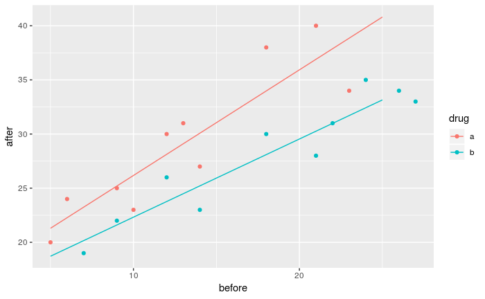

```r
ggplot(prepost, aes(x=before,y=after,colour=drug))+
  geom_point()+
  geom_line(data=preds,aes(y=pred))
```

lines are approx parallel (given amount of variability), supporting lack of interaction.

Or, more simply:

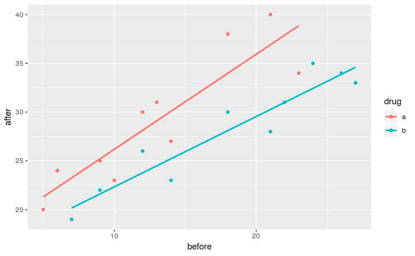

```r
ggplot(prepost,
aes(x=before,y=after,colour=drug))+
  geom_point()+
  geom_smooth(method="lm", se=F)
```

In a moment, though, need more complicated way.

Take out interaction:

```r
prepost.2=update(prepost.1,.~.-before:drug)
anova(prepost.2)
```

```
Analysis of Variance Table

Response: after
          Df Sum Sq Mean Sq F value    Pr(>F)
before     1 430.92  430.92  59.890 5.718e-07 ***
drug       1 115.31  115.31  16.025 0.0009209 ***
Residuals 17 122.32    7.20
---
Signif. codes:  0 ‘***’ 0.001 ‘**’ 0.01 ‘*’ 0.05 ‘.’ 0.1 ‘ ’ 1
```

Strong main effects of `before` and `drug`.

Do predictions from this model:

```r
pred=predict(prepost.2,new)
preds=bind_cols(new,pred=pred)
preds
```

| before | drug | pred |
| --- | --- | --- |
| 5 | a | 22.49740 |
| 5 | b | 17.34274 |
| 15 | a | 30.77221 |
| 15 | b | 25.61756 |
| 25 | a | 39.04703 |
| 25 | b | 33.89237 |

Each increase of 10 in before score results in 8.3 in predicted after score, *the same for both drugs*. (Implication of no interaction.)

Plot again, code as before:

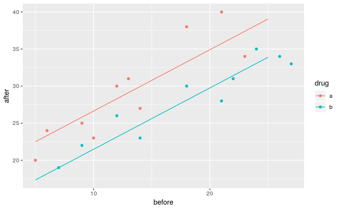

```r
ggplot(prepost,
  aes(x=before,y=after,colour=drug))+
  geom_point()+
  geom_line(data=preds,aes(y=pred))
```

This time, lines are *exactly* parallel (model says they must be).

Different look at model output, as “regression”:

```r
summary(prepost.2)
```

```
Call:
lm(formula = after ~ before + drug, data = prepost)

Residuals:
    Min      1Q  Median      3Q     Max
-3.6348 -2.5099 -0.2038  1.8871  4.7453

Coefficients:
            Estimate Std. Error t value Pr(>|t|)
(Intercept)  18.3600     1.5115  12.147 8.35e-10 ***
before        0.8275     0.0955   8.665 1.21e-07 ***
drugb        -5.1547     1.2876  -4.003 0.000921 ***
---
Signif. codes:  0 ‘***’ 0.001 ‘**’ 0.01 ‘*’ 0.05 ‘.’ 0.1 ‘ ’ 1

Residual standard error: 2.682 on 17 degrees of freedom
Multiple R-squared:  0.817, Adjusted R-squared:  0.7955
F-statistic: 37.96 on 2 and 17 DF,  p-value: 5.372e-07
```

```r
summary(prepost.1)
```

```
Call:
lm(formula = after ~ before * drug, data = prepost)

Residuals:
    Min      1Q  Median      3Q     Max
-4.8562 -1.7500  0.0696  1.8982  4.0207

Coefficients:
             Estimate Std. Error t value Pr(>|t|)
(Intercept)   16.4226     2.0674   7.944 6.08e-07 ***
before         0.9754     0.1446   6.747 4.69e-06 ***
drugb         -1.3139     3.1310  -0.420    0.680
before:drugb  -0.2536     0.1893  -1.340    0.199
---
Signif. codes:  0 ‘***’ 0.001 ‘**’ 0.01 ‘*’ 0.05 ‘.’ 0.1 ‘ ’ 1

Residual standard error: 2.622 on 16 degrees of freedom
Multiple R-squared:  0.8355,    Adjusted R-squared:  0.8046
F-statistic: 27.09 on 3 and 16 DF,  p-value: 1.655e-06
```

slide 286 for discussion

## Multivariate analysis of variance (MANOVA)

slide 289

seed yields and weights:

```r
my_url="http://www.utsc.utoronto.ca/~butler/d29/manova1.txt"
hilo=read_delim(my_url," ")
hilo
```

| fertilizer | yield | weight |
| --- | --- | --- |
| low | 34 | 10 |
| low | 29 | 14 |
| low | 35 | 11 |
| low | 32 | 13 |
| high | 33 | 14 |
| high | 38 | 12 |
| high | 34 | 13 |
| high | 35 | 14 |

boxplots: yield by fertilizer:

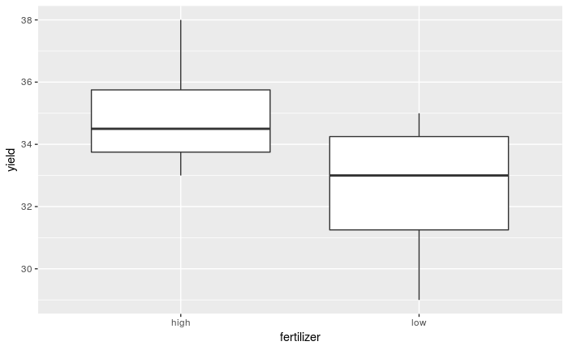

```r
ggplot(hilo,aes(x=fertilizer,y=yield))+geom_boxplot()
```

and weight by fertilizer

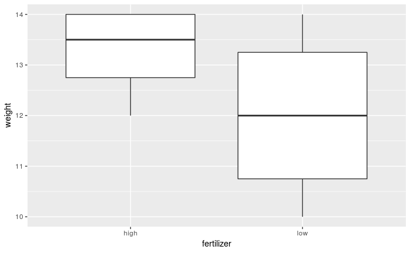

```r
ggplot(hilo,aes(x=fertilizer,y=weight))+geom_boxplot()
```

Not convincing evidence of difference on either plot.

One-way ANOVAs:

```r
hilo.y=aov(yield~fertilizer,data=hilo)
summary(hilo.y)
```

```
            Df Sum Sq Mean Sq F value Pr(>F)
fertilizer   1   12.5  12.500   2.143  0.194
Residuals    6   35.0   5.833
```

and

```r
hilo.w=aov(weight~fertilizer,data=hilo)
summary(hilo.w)
```

```
            Df Sum Sq Mean Sq F value Pr(>F)
fertilizer   1  3.125   3.125   1.471  0.271
Residuals    6 12.750   2.125
```

Neither significant.

But, a better plot, of the two responses against each other labelled by fertilizer:

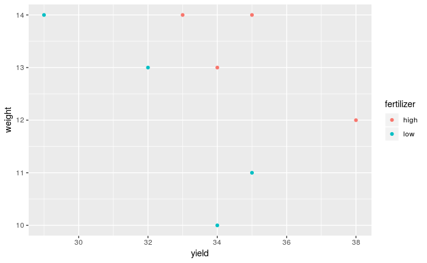

```r
g=ggplot(hilo,aes(x=yield,y=weight,
  colour=fertilizer))+geom_point()
g
```

I add a line to this, for reasons that will become clear:

```r
d=tribble(
  ~line_x, ~line_y,
  31, 14,
  38, 10)
d
```

| line_x | line_y |
| --- | --- |
| 31 | 14 |
| 38 | 10 |

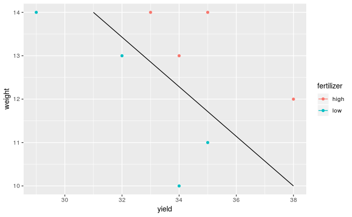

```r
g+geom_line(data=d,aes(x=line_x,y=line_y,colour=NULL))
```

slide 298

Is there an effect of fertilizer on yield and weight combined? This is what MANOVA finds out.

```r
response=with(hilo,cbind(yield,weight))

hilo.1=manova(response~fertilizer, data=hilo)
summary(hilo.1)
```

```
           Df  Pillai approx F num Df den Df  Pr(>F)
fertilizer  1 0.80154   10.097      2      5 0.01755 *
Residuals   6
---
Signif. codes:  0 ‘***’ 0.001 ‘**’ 0.01 ‘*’ 0.05 ‘.’ 0.1 ‘ ’ 1
```

Neither yield or weight individually are affected by fertilizer, but *in combination* they are.

slide 300

Another way to do the same thing, from package `car`:

```r
hilo.2=lm(response~fertilizer,data=hilo)
Manova(hilo.2)
```

```
Type II MANOVA Tests: Pillai test statistic
           Df test stat approx F num Df den Df  Pr(>F)
fertilizer  1   0.80154   10.097      2      5 0.01755 *
---
Signif. codes:  0 ‘***’ 0.001 ‘**’ 0.01 ‘*’ 0.05 ‘.’ 0.1 ‘ ’ 1
```

with the same result. (We have to do repeated measures, later, this way, but you can do MANOVA either way.)

```r
summary(Manova(hilo.2))
```

```
Type II MANOVA Tests:

Sum of squares and products for error:
       yield weight
yield     35 -18.00
weight   -18  12.75

------------------------------------------

Term: fertilizer

Sum of squares and products for the hypothesis:
       yield weight
yield  12.50  6.250
weight  6.25  3.125

Multivariate Tests: fertilizer
                 Df test stat approx F num Df den Df   Pr(>F)
Pillai            1  0.801542 10.09714      2      5 0.017546 *
Wilks             1  0.198458 10.09714      2      5 0.017546 *
Hotelling-Lawley  1  4.038855 10.09714      2      5 0.017546 *
Roy               1  4.038855 10.09714      2      5 0.017546 *
---
Signif. codes:  0 ‘***’ 0.001 ‘**’ 0.01 ‘*’ 0.05 ‘.’ 0.1 ‘ ’ 1
```

Peanuts example slide 303

```r
my_url="http://www.utsc.utoronto.ca/~butler/d29/peanuts.txt"
(peanuts.orig=read_delim(my_url," "))
```

| obs | location | variety | y | smk | w |
| --- | --- | --- | --- | --- | --- |
| 1 | 1 | 5 | 195.3 | 153.1 | 51.4 |
| 2 | 1 | 5 | 194.3 | 167.7 | 53.7 |
| 3 | 2 | 5 | 189.7 | 139.5 | 55.5 |
| 4 | 2 | 5 | 180.4 | 121.1 | 44.4 |
| 5 | 1 | 6 | 203.0 | 156.8 | 49.8 |
| 6 | 1 | 6 | 195.9 | 166.0 | 45.8 |
| 7 | 2 | 6 | 202.7 | 166.1 | 60.4 |
| 8 | 2 | 6 | 197.6 | 161.8 | 54.1 |
| 9 | 1 | 8 | 193.5 | 164.5 | 57.8 |
| 10 | 1 | 8 | 187.0 | 165.1 | 58.6 |

[output cut: 2 more lines]

Location and variety are really categorical; `y`, `smk`, `w` are quantitative responses.

```r
peanuts.orig %>%
  mutate(location=factor(location),
  variety=factor(variety)) -> peanuts
peanuts
```

| obs | location | variety | y | smk | w |
| --- | --- | --- | --- | --- | --- |
| 1 | 1 | 5 | 195.3 | 153.1 | 51.4 |
| 2 | 1 | 5 | 194.3 | 167.7 | 53.7 |
| 3 | 2 | 5 | 189.7 | 139.5 | 55.5 |
| 4 | 2 | 5 | 180.4 | 121.1 | 44.4 |
| 5 | 1 | 6 | 203.0 | 156.8 | 49.8 |
| 6 | 1 | 6 | 195.9 | 166.0 | 45.8 |
| 7 | 2 | 6 | 202.7 | 166.1 | 60.4 |
| 8 | 2 | 6 | 197.6 | 161.8 | 54.1 |
| 9 | 1 | 8 | 193.5 | 164.5 | 57.8 |
| 10 | 1 | 8 | 187.0 | 165.1 | 58.6 |

[output cut: 2 more lines]

create response

```r
response=with(peanuts,cbind(y,smk,w))
class(response)
```

```
[1] "matrix"
```

```r
response
```

```
          y   smk    w
 [1,] 195.3 153.1 51.4
 [2,] 194.3 167.7 53.7
 [3,] 189.7 139.5 55.5
 [4,] 180.4 121.1 44.4
 [5,] 203.0 156.8 49.8
 [6,] 195.9 166.0 45.8
 [7,] 202.7 166.1 60.4
 [8,] 197.6 161.8 54.1
 [9,] 193.5 164.5 57.8
[10,] 187.0 165.1 58.6
[11,] 201.5 166.8 65.0
[12,] 200.0 173.8 67.2
```

Analysis uses `Manova`:

```r
peanuts.1=lm(response~location*variety,data=peanuts)
Manova(peanuts.1)
```

```
Type II MANOVA Tests: Pillai test statistic
                 Df test stat approx F num Df den Df   Pr(>F)
location          1   0.89348  11.1843      3      4 0.020502 *
variety           2   1.70911   9.7924      6     10 0.001056 **
location:variety  2   1.29086   3.0339      6     10 0.058708 .
---
Signif. codes:  0 ‘***’ 0.001 ‘**’ 0.01 ‘*’ 0.05 ‘.’ 0.1 ‘ ’ 1
```

or not, as you prefer:

```r
peanuts.3=manova(response~location*variety, data=peanuts)
summary(peanuts.3)
```

```
                 Df  Pillai approx F num Df den Df   Pr(>F)
location          1 0.89348  11.1843      3      4 0.020502 *
variety           2 1.70911   9.7924      6     10 0.001056 **
location:variety  2 1.29086   3.0339      6     10 0.058708 .
Residuals         6
---
Signif. codes:  0 ‘***’ 0.001 ‘**’ 0.01 ‘*’ 0.05 ‘.’ 0.1 ‘ ’ 1
```

Interaction term is almost significant, so there might be a dependence of the 3-variable response on location-variety combination.

Understanding that requires a 3D plot or discriminant analysis (later).

More detail:

```r
summary(Manova(peanuts.1))
```

```
Type II MANOVA Tests:

Sum of squares and products for error:
          y     smk       w
y   104.205  49.365  76.480
smk  49.365 352.105 121.995
w    76.480 121.995  94.835

------------------------------------------

Term: location

Sum of squares and products for the hypothesis:
              y       smk           w
y     0.7008333  -10.6575    7.129167
smk -10.6575000  162.0675 -108.412500
w     7.1291667 -108.4125   72.520833

Multivariate Tests: location
                 Df test stat approx F num Df den Df   Pr(>F)
Pillai            1  0.893484 11.18432      3      4 0.020502 *
Wilks             1  0.106516 11.18432      3      4 0.020502 *
Hotelling-Lawley  1  8.388243 11.18432      3      4 0.020502 *
Roy               1  8.388243 11.18432      3      4 0.020502 *
---
Signif. codes:  0 ‘***’ 0.001 ‘**’ 0.01 ‘*’ 0.05 ‘.’ 0.1 ‘ ’ 1

------------------------------------------

Term: variety

Sum of squares and products for the hypothesis:
           y       smk        w
y   196.1150  365.1825  42.6275
smk 365.1825 1089.0150 414.6550
w    42.6275  414.6550 284.1017

Multivariate Tests: variety
                 Df test stat  approx F num Df den Df    Pr(>F)
Pillai            2  1.709109  9.792388      6     10 0.0010562 **
```

[output cut: 9 more lines]

```

Sum of squares and products for the hypothesis:
           y      smk         w
y   205.1017 363.6675 107.78583
smk 363.6675 780.6950 254.22000
w   107.7858 254.2200  85.95167

Multivariate Tests: location:variety
                 Df test stat  approx F num Df den Df   Pr(>F)
Pillai            2  1.290861  3.033867      6     10 0.058708 .
Wilks             2  0.074300  3.558197      6      8 0.050794 .
Hotelling-Lawley  2  7.544290  3.772145      6      6 0.065517 .
Roy               2  6.824094 11.373490      3      5 0.011340 *
---
Signif. codes:  0 ‘***’ 0.001 ‘**’ 0.01 ‘*’ 0.05 ‘.’ 0.1 ‘ ’ 1
```

## Repeated measures

slide 307

Histamine in dogs:

```r
my_url="http://www.utsc.utoronto.ca/~butler/d29/dogs.txt"
dogs=read_table(my_url)
dogs
```

| dog | drug | x | lh0 | lh1 | lh3 | lh5 |
| --- | --- | --- | --- | --- | --- | --- |
| A | Morphine | N | -3.22 | -1.61 | -2.30 | -2.53 |
| B | Morphine | N | -3.91 | -2.81 | -3.91 | -3.91 |
| C | Morphine | N | -2.66 | 0.34 | -0.73 | -1.43 |
| D | Morphine | N | -1.77 | -0.56 | -1.05 | -1.43 |
| E | Trimethaphan | N | -3.51 | -0.48 | -1.17 | -1.51 |
| F | Trimethaphan | N | -3.51 | 0.05 | -0.31 | -0.51 |
| G | Trimethaphan | N | -2.66 | -0.19 | 0.07 | -0.22 |
| H | Trimethaphan | N | -2.41 | 1.14 | 0.72 | 0.21 |

Four response columns (histamine levels at different times).

Going the `Manova` way for analysis:

```r
response=with(dogs,cbind(lh0,lh1,lh3,lh5))
dogs.1=lm(response~drug,data=dogs)
```

We have some extra setup to express that these are the same thing measured at different times:

```r
response
```

```
       lh0   lh1   lh3   lh5
[1,] -3.22 -1.61 -2.30 -2.53
[2,] -3.91 -2.81 -3.91 -3.91
[3,] -2.66  0.34 -0.73 -1.43
[4,] -1.77 -0.56 -1.05 -1.43
[5,] -3.51 -0.48 -1.17 -1.51
[6,] -3.51  0.05 -0.31 -0.51
[7,] -2.66 -0.19  0.07 -0.22
[8,] -2.41  1.14  0.72  0.21
```

```r
times=colnames(response)
times.df=data.frame(times)
```

What are these?

```r
times
```

```
[1] "lh0" "lh1" "lh3" "lh5"
```

and

```r
times.df
```

| times |
| --- |
| lh0 |
| lh1 |
| lh3 |
| lh5 |

note that `times` has gotten turned into a factor. `tibble` doesn’t work (instead of `data.frame`) because it doesn’t create factors (unless you make it do so).

Then the analysis

```r
Manova(dogs.1, idata=times.df, idesign=~times)
```

```
Type II Repeated Measures MANOVA Tests: Pillai test statistic
            Df test stat approx F num Df den Df   Pr(>F)
(Intercept)  1   0.76347  19.3664      1      6 0.004565 **
drug         1   0.34263   3.1272      1      6 0.127406
times        1   0.94988  25.2690      3      4 0.004631 **
drug:times   1   0.89476  11.3362      3      4 0.020023 *
---
Signif. codes:  0 ‘***’ 0.001 ‘**’ 0.01 ‘*’ 0.05 ‘.’ 0.1 ‘ ’ 1
```

The effect of drug is different at different times.

To investigate what, we can draw a graph. But we have wide format:

```r
dogs
```

| dog | drug | x | lh0 | lh1 | lh3 | lh5 |
| --- | --- | --- | --- | --- | --- | --- |
| A | Morphine | N | -3.22 | -1.61 | -2.30 | -2.53 |
| B | Morphine | N | -3.91 | -2.81 | -3.91 | -3.91 |
| C | Morphine | N | -2.66 | 0.34 | -0.73 | -1.43 |
| D | Morphine | N | -1.77 | -0.56 | -1.05 | -1.43 |
| E | Trimethaphan | N | -3.51 | -0.48 | -1.17 | -1.51 |
| F | Trimethaphan | N | -3.51 | 0.05 | -0.31 | -0.51 |
| G | Trimethaphan | N | -2.66 | -0.19 | 0.07 | -0.22 |
| H | Trimethaphan | N | -2.41 | 1.14 | 0.72 | 0.21 |

and we want all the histamine levels in *one* column:

```r
dogs %>% gather(timex,lh,lh0:lh5)
```

| dog | drug | x | timex | lh |
| --- | --- | --- | --- | --- |
| A | Morphine | N | lh0 | -3.22 |
| B | Morphine | N | lh0 | -3.91 |
| C | Morphine | N | lh0 | -2.66 |
| D | Morphine | N | lh0 | -1.77 |
| E | Trimethaphan | N | lh0 | -3.51 |
| F | Trimethaphan | N | lh0 | -3.51 |
| G | Trimethaphan | N | lh0 | -2.66 |
| H | Trimethaphan | N | lh0 | -2.41 |
| A | Morphine | N | lh1 | -1.61 |
| B | Morphine | N | lh1 | -2.81 |

[output cut: 22 more lines]

Can we get the times as *numbers*?

```r
dogs %>% gather(timex,lh,lh0:lh5) %>%
  mutate(time=parse_number(timex)) -> dogs.long
dogs.long
```

| dog | drug | x | timex | lh | time |
| --- | --- | --- | --- | --- | --- |
| A | Morphine | N | lh0 | -3.22 | 0 |
| B | Morphine | N | lh0 | -3.91 | 0 |
| C | Morphine | N | lh0 | -2.66 | 0 |
| D | Morphine | N | lh0 | -1.77 | 0 |
| E | Trimethaphan | N | lh0 | -3.51 | 0 |
| F | Trimethaphan | N | lh0 | -3.51 | 0 |
| G | Trimethaphan | N | lh0 | -2.66 | 0 |
| H | Trimethaphan | N | lh0 | -2.41 | 0 |
| A | Morphine | N | lh1 | -1.61 | 1 |
| B | Morphine | N | lh1 | -2.81 | 1 |

[output cut: 22 more lines]

Make an interaction plot of log-histamine against time, labelled by drug:

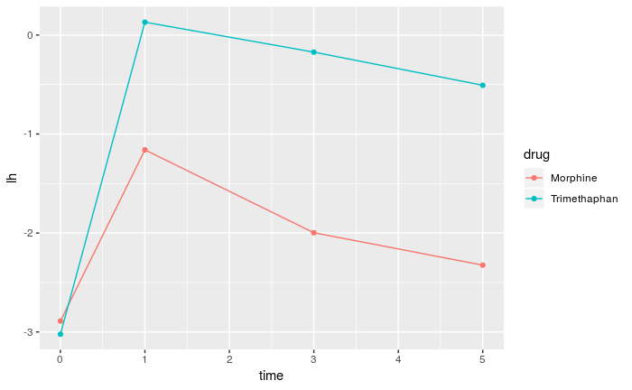

```r
ggplot(dogs.long,aes(x=time, y=lh ,colour=drug, group=drug))+
  stat_summary(fun.y=mean,geom="point")+
  stat_summary(fun.y=mean,geom="line")
```

This shows that log-histamine levels are similar at time zero, but for all times after that, trimethaphan log-histamine levels are higher.

I could add the data:

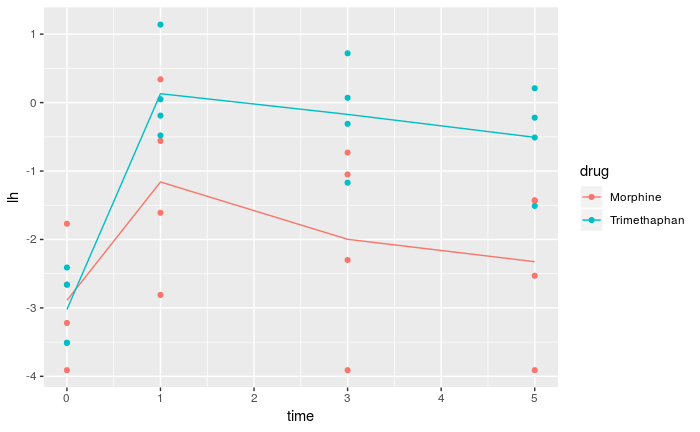

```r
ggplot(dogs.long,aes(x=time, y=lh, colour=drug, group=drug))+
  stat_summary(fun.y=mean,geom="line")+
  geom_point()
```

The log-histamine levels really are all mixed up at time zero, and the blue points really are higher than the red ones after that. This explains the significant interaction.

Time zero really ought not to be included in the analysis, because there is no time for the drugs to have an effect. (There is usually a value noted at time zero so that we can confirm the drugs were not different then.)

So let’s go back to the original data frame and exclude time zero. This means redefining the response and following through:

```r
response=with(dogs,cbind(lh1, lh3, lh5)) # excluding time zero
dogs.2=lm(response~drug, data=dogs)
times=colnames(response)
times
```

```
[1] "lh1" "lh3" "lh5"
```

```r
times.df=data.frame(times)
times.df
```

| times |
| --- |
| lh1 |
| lh3 |
| lh5 |

```r
Manova(dogs.2,idata=times.df, idesign=~times)
```

```
Type II Repeated Measures MANOVA Tests: Pillai test statistic
            Df test stat approx F num Df den Df   Pr(>F)
(Intercept)  1   0.54582   7.2106      1      6 0.036281 *
drug         1   0.44551   4.8207      1      6 0.070527 .
times        1   0.85429  14.6569      2      5 0.008105 **
drug:times   1   0.43553   1.9289      2      5 0.239390
---
Signif. codes:  0 ‘***’ 0.001 ‘**’ 0.01 ‘*’ 0.05 ‘.’ 0.1 ‘ ’ 1
```

The interaction is no longer significant.

Cannot take it out (interaction of “within-subject” factor `times` and “between-subject” factor `drug`). So ignore it, because it is non-significant, and interpret the main effects: an effect of time, but an only marginally significant effect of drug.

A better plot for repeated-measures data is to join measurements on the same individual: a “spaghetti plot”, thus:

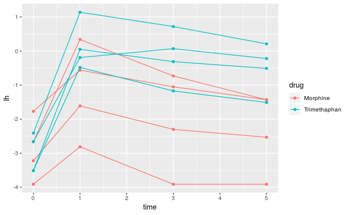

```r
ggplot(dogs.long,aes(x=time, y=lh, colour=drug, group=dog)) +
  geom_point()+geom_line()
```

Mixed model approach, using `lme4`:

Make sure to use the *text* time instead of the numerical time, to get it treated as categorical (otherwise gets treated as regression, linear in time, which it is not).

```r
dogs.3=lmer(lh~timex*drug+(1|dog), data=dogs.long)
drop1(dogs.3, test="Chisq")
```

```
Single term deletions

Model:
lh ~ timex * drug + (1 | dog)
           Df    AIC    LRT   Pr(Chi)
<none>        62.167
timex:drug  3 84.589 28.422 2.962e-06 ***
---
Signif. codes:  0 ‘***’ 0.001 ‘**’ 0.01 ‘*’ 0.05 ‘.’ 0.1 ‘ ’ 1
```

This time the interaction is strongly significant.

or omit time zero:

```r
dogs.long %>% filter(time>0) -> d
dogs.4=lmer(lh~timex*drug+(1|dog), data=d)
drop1(dogs.4, test="Chisq")
```

```
Single term deletions

Model:
lh ~ timex * drug + (1 | dog)
           Df    AIC    LRT Pr(Chi)
<none>        42.119
timex:drug  2 44.771 6.6518 0.03594 *
---
Signif. codes:  0 ‘***’ 0.001 ‘**’ 0.01 ‘*’ 0.05 ‘.’ 0.1 ‘ ’ 1
```

this time the interaction is still significant.

Another example: exercise, see slide 325.

```r
my_url="http://www.utsc.utoronto.ca/~butler/d29/exercise.txt"
exercise.long=read_tsv(my_url)
exercise.long
```

| id | diet | exertype | pulse | time |
| --- | --- | --- | --- | --- |
| 1 | nonlowfat | atrest | 85 | min01 |
| 1 | nonlowfat | atrest | 85 | min15 |
| 1 | nonlowfat | atrest | 88 | min30 |
| 2 | nonlowfat | atrest | 90 | min01 |
| 2 | nonlowfat | atrest | 92 | min15 |
| 2 | nonlowfat | atrest | 93 | min30 |
| 3 | nonlowfat | atrest | 97 | min01 |
| 3 | nonlowfat | atrest | 97 | min15 |
| 3 | nonlowfat | atrest | 94 | min30 |
| 4 | nonlowfat | atrest | 80 | min01 |

[output cut: 80 more lines]

Diet and exercise type are between-subjects, but time is within-subjects. (Each subject does one diet and one type of exercise all the way through, but is measured at several different times.)

Make *wide* for analysis:

```r
exercise.long %>% spread(time, pulse) -> exercise.wide
exercise.wide
```

| id | diet | exertype | min01 | min15 | min30 |
| --- | --- | --- | --- | --- | --- |
| 1 | nonlowfat | atrest | 85 | 85 | 88 |
| 2 | nonlowfat | atrest | 90 | 92 | 93 |
| 3 | nonlowfat | atrest | 97 | 97 | 94 |
| 4 | nonlowfat | atrest | 80 | 82 | 83 |
| 5 | nonlowfat | atrest | 91 | 92 | 91 |
| 6 | lowfat | atrest | 83 | 83 | 84 |
| 7 | lowfat | atrest | 87 | 88 | 90 |
| 8 | lowfat | atrest | 92 | 94 | 95 |
| 9 | lowfat | atrest | 97 | 99 | 96 |
| 10 | lowfat | atrest | 100 | 97 | 100 |

[output cut: 20 more lines]

Make response:

```r
response=with(exercise.wide, cbind(min01, min15, min30))
```

Predict from diet and exercise type:

```r
exercise.1=lm(response~diet*exertype, data=exercise.wide)
```

Manova:

```r
times=colnames(response)
times.df=data.frame(times)
Manova(exercise.1, idata=times.df, idesign=~times)
```

```
Type II Repeated Measures MANOVA Tests: Pillai test statistic
                    Df test stat approx F num Df den Df    Pr(>F)
(Intercept)          1   0.99767  10296.7      1     24 < 2.2e-16 ***
diet                 1   0.37701     14.5      1     24 0.0008483 ***
exertype             2   0.79972     47.9      2     24 4.166e-09 ***
diet:exertype        2   0.28120      4.7      2     24 0.0190230 *
times                1   0.78182     41.2      2     23 2.491e-08 ***
diet:times           1   0.25153      3.9      2     23 0.0357258 *
exertype:times       2   0.83557      8.6      4     48 2.538e-05 ***
diet:exertype:times  2   0.51750      4.2      4     48 0.0054586 **
---
Signif. codes:  0 ‘***’ 0.001 ‘**’ 0.01 ‘*’ 0.05 ‘.’ 0.1 ‘ ’ 1
```

Now have significant *three*-way interaction: the effect of the combination of diet and exercise type is itself different at different times.

Spaghetti plot:

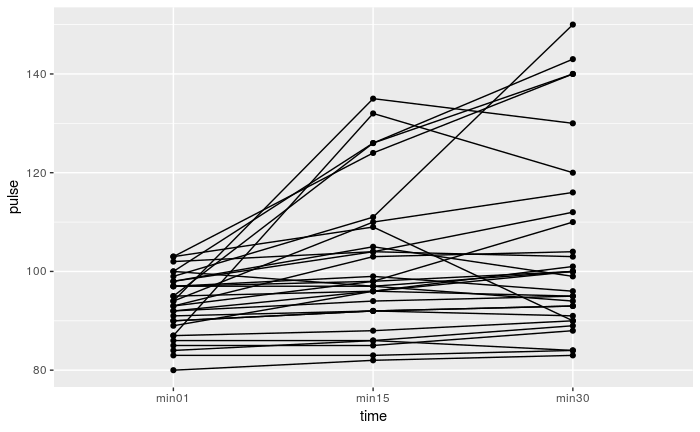

```r
ggplot(exercise.long, aes(x=time, y=pulse, group=id))+
  geom_point()+geom_line()
```

but normally we’d have a colour = something, and here we have two somethings: diet and exercise type. So instead have facets for these. With two things to facet by, use `facet_grid` to have one as rows and the other as columns:

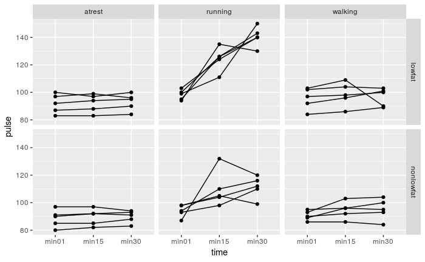

```r
ggplot(exercise.long, aes(x=time, y=pulse, group=id))+
  geom_point()+geom_line()+
  facet_grid(diet~exertype)
```

Only for exercise type running is there any time effect worth noting.

Can I do “simple effects” of diet for the runners?

Pull out only the runners first:

```r
exercise.wide %>%
  filter(exertype=="running") -> runners.wide
```

and then redo all the same analysis on this data frame:

```r
response=with(runners.wide, cbind(min01, min15, min30))
runners.1=lm(response~diet, data=runners.wide)
times=colnames(response)
times.df=data.frame(times)
Manova(runners.1, idata=times.df, idesign=~times)
```

```
Type II Repeated Measures MANOVA Tests: Pillai test statistic
            Df test stat approx F num Df den Df    Pr(>F)
(Intercept)  1   0.99912   9045.3      1      8 1.668e-13 ***
diet         1   0.84986     45.3      1      8 0.0001482 ***
times        1   0.92493     43.1      2      7 0.0001159 ***
diet:times   1   0.68950      7.8      2      7 0.0166807 *
---
Signif. codes:  0 ‘***’ 0.001 ‘**’ 0.01 ‘*’ 0.05 ‘.’ 0.1 ‘ ’ 1
```

Even for the runners, the effect of time is still different for each diet.

Now that we are just focusing on one exercise type, we can do an interaction plot, for which we need long data:

```r
runners.wide
```

| id | diet | exertype | min01 | min15 | min30 |
| --- | --- | --- | --- | --- | --- |
| 21 | nonlowfat | running | 93 | 98 | 110 |
| 22 | nonlowfat | running | 98 | 104 | 112 |
| 23 | nonlowfat | running | 98 | 105 | 99 |
| 24 | nonlowfat | running | 87 | 132 | 120 |
| 25 | nonlowfat | running | 94 | 110 | 116 |
| 26 | lowfat | running | 95 | 126 | 143 |
| 27 | lowfat | running | 100 | 126 | 140 |
| 28 | lowfat | running | 103 | 124 | 140 |
| 29 | lowfat | running | 94 | 135 | 130 |
| 30 | lowfat | running | 99 | 111 | 150 |

```r
runners.wide %>% gather(time, pulse, min01:min30) -> runners.long
runners.long
```

| id | diet | exertype | time | pulse |
| --- | --- | --- | --- | --- |
| 21 | nonlowfat | running | min01 | 93 |
| 22 | nonlowfat | running | min01 | 98 |
| 23 | nonlowfat | running | min01 | 98 |
| 24 | nonlowfat | running | min01 | 87 |
| 25 | nonlowfat | running | min01 | 94 |
| 26 | lowfat | running | min01 | 95 |
| 27 | lowfat | running | min01 | 100 |
| 28 | lowfat | running | min01 | 103 |
| 29 | lowfat | running | min01 | 94 |
| 30 | lowfat | running | min01 | 99 |

[output cut: 20 more lines]

(the other way of doing this is to start with `exercise.long` and filter the runners.)

and then the interaction plot:

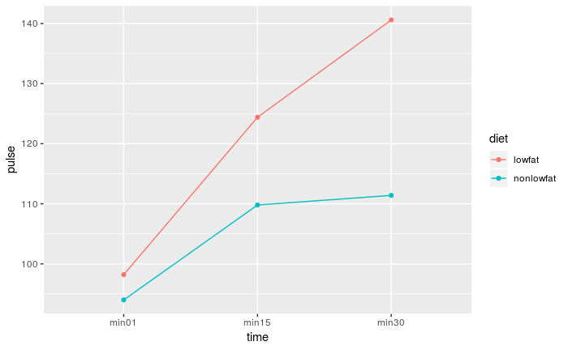

```r
ggplot(runners.long, aes(x=time, y=pulse, colour=diet, group=diet))+
  stat_summary(fun.y=mean, geom="point") +
  stat_summary(fun.y=mean, geom="line")
```

These are not parallel: the difference in (mean) pulse rates gets larger as time passes. Is this real? Look at spaghetti plot:

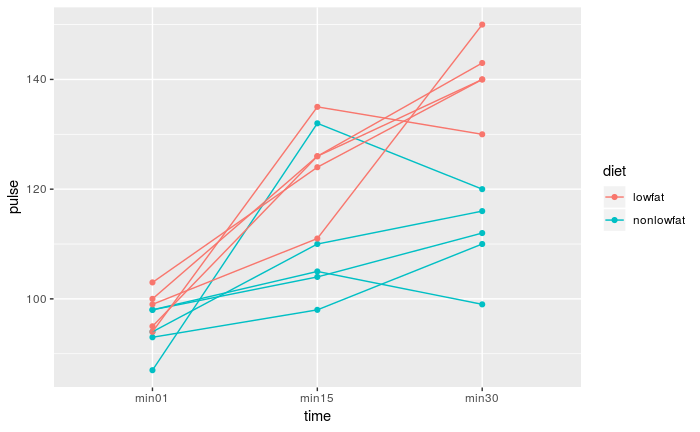

```r
ggplot(runners.long, aes(x=time, y=pulse, colour=diet, group=id))+
  geom_point()+geom_line()
```

At 1 minute, the pulse rates are all mixed up, at 15 minutes the lowfat ones are mostly higher, and at 30 minutes they are all clearly higher. (What would happen if we took out “time zero”, namely 1 minute?)

```r
response=with(runners.wide, cbind(min15, min30))
runners.3=lm(response~diet, data=runners.wide)
times=colnames(response)
times.df=data.frame(times)
Manova(runners.3, idata=times.df, idesign=~times)
```

```
Type II Repeated Measures MANOVA Tests: Pillai test statistic
            Df test stat approx F num Df den Df    Pr(>F)
(Intercept)  1   0.99746  3146.00      1      8 1.133e-11 ***
diet         1   0.76142    25.53      1      8 0.0009857 ***
times        1   0.36367     4.57      1      8 0.0649557 .
diet:times   1   0.27771     3.08      1      8 0.1175467
---
Signif. codes:  0 ‘***’ 0.001 ‘**’ 0.01 ‘*’ 0.05 ‘.’ 0.1 ‘ ’ 1
```

The interaction is no longer significant. There is a marginally significant time effect (comparing 15 minutes and 30 minutes), and a definite diet effect.